# Assignment-3-chadalab

**1. Data Preprocessing:**

• Load the dataset and perform initial exploratory data analysis.

• Handle null values appropriately (e.g., using imputation or removal).

• Convert categorical variables to a suitable numerical format.

• Encode the target variable 'Segmentation' for the classification task.

```
       ID  Gender Ever_Married  Age Graduated     Profession  Work_Experience  \
0  462809    Male           No   22        No     Healthcare              1.0
1  462643  Female          Yes   38       Yes       Engineer              NaN
2  466315  Female          Yes   67       Yes       Engineer              1.0
3  461735    Male          Yes   67       Yes         Lawyer              0.0
4  462669  Female          Yes   40       Yes  Entertainment              NaN

  Spending_Score  Family_Size  Var_1 Segmentation
0            Low          4.0  Cat_4            D
1        Average          3.0  Cat_4            A
2            Low          1.0  Cat_6            B
3           High          2.0  Cat_6            B
4           High          6.0  Cat_6            A
<class 'pandas.core.frame.DataFrame'>
RangeIndex: 8068 entries, 0 to 8067
Data columns (total 11 columns):
 #   Column           Non-Null Count  Dtype
---  ------           --------------  -----
 0   ID               8068 non-null   int64
 1   Gender           8068 non-null   object
 2   Ever_Married     7928 non-null   object
 3   Age              8068 non-null   int64
 4   Graduated        7990 non-null   object
 5   Profession       7944 non-null   object
 6   Work_Experience  7239 non-null   float64
 7   Spending_Score   8068 non-null   object
 8   Family_Size      7733 non-null   float64
 9   Var_1            7992 non-null   object
 10  Segmentation     8068 non-null   object
dtypes: float64(2), int64(2), object(7)
memory usage: 693.5+ KB
None
ID                   0
Gender               0
Ever_Married       140
Age                  0
Graduated           78
Profession         124
Work_Experience    829
Spending_Score       0
Family_Size        335
Var_1               76
Segmentation         0
dtype: int64
3    2268
0    1972
2    1970
1    1858
Name: Segmentation, dtype: int64
```

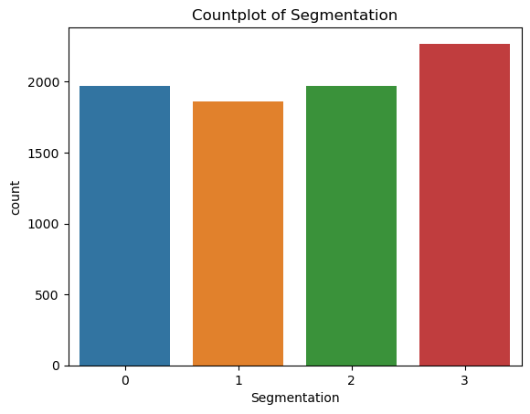

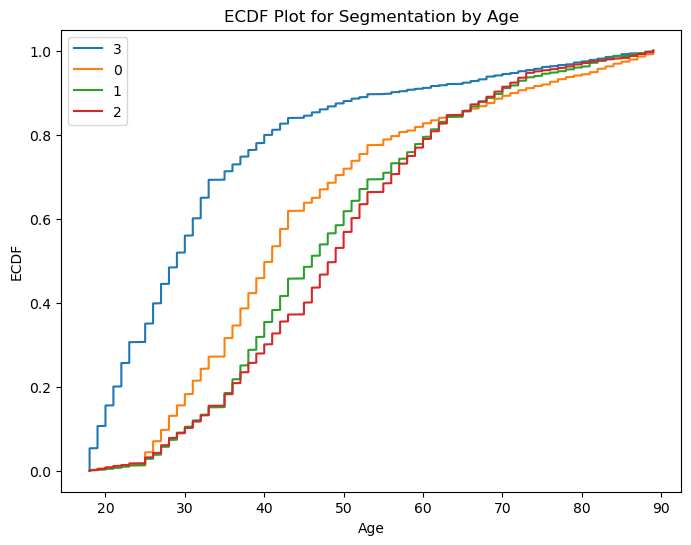

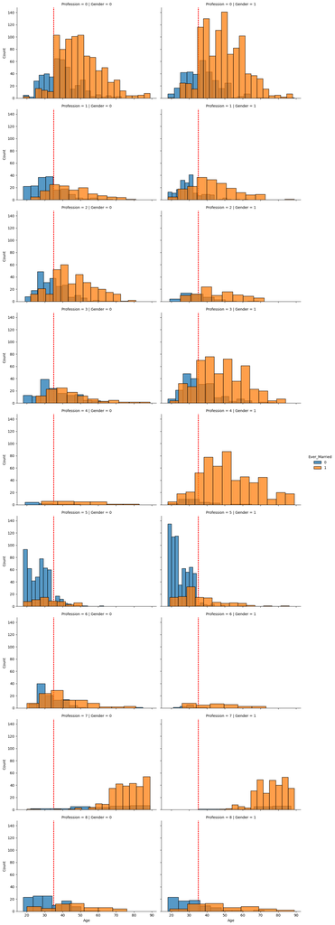

```python
import warnings

# Suppress all warnings
warnings.filterwarnings("ignore")


warnings.filterwarnings("default")
import pandas as pd
from sklearn.preprocessing import LabelEncoder

# Load the dataset
data = pd.read_csv("train.csv")

# Initial exploratory data analysis
print(data.head())  # Display the first few rows of the dataset
print(data.info())  # Display information about the dataset

# Handle null values
print(data.isnull().sum())  # Check for null values in each column
# Assuming that there are null values in the dataset, we'll handle them using imputation
# For numerical columns, we can impute with mean or median, and for categorical columns, we can impute with mode

# Impute numerical columns with mean
data['Age'].fillna(data['Age'].mean(), inplace=True)
data['Work_Experience'].fillna(data['Work_Experience'].mean(), inplace=True)
data['Family_Size'].fillna(data['Family_Size'].mean(), inplace=True)

# Impute categorical columns with mode
data['Ever_Married'].fillna(data['Ever_Married'].mode()[0], inplace=True)
data['Graduated'].fillna(data['Graduated'].mode()[0], inplace=True)
data['Profession'].fillna(data['Profession'].mode()[0], inplace=True)
data['Var_1'].fillna(data['Var_1'].mode()[0], inplace=True)

# Convert categorical variables to numerical format
# Using LabelEncoder for simplicity
label_encoder = LabelEncoder()
data['Gender'] = label_encoder.fit_transform(data['Gender'])
data['Ever_Married'] = label_encoder.fit_transform(data['Ever_Married'])
data['Graduated'] = label_encoder.fit_transform(data['Graduated'])
data['Profession'] = label_encoder.fit_transform(data['Profession'])
data['Spending_Score'] = label_encoder.fit_transform(data['Spending_Score'])
data['Var_1'] = label_encoder.fit_transform(data['Var_1'])

# Encode the target variable 'Segmentation' for classification task
data['Segmentation'] = label_encoder.fit_transform(data['Segmentation'])

# Check the encoded values for 'Segmentation'
print(data['Segmentation'].value_counts())

# Now, the data is preprocessed and ready for further analysis or modeling
import seaborn as sns
import matplotlib.pyplot as plt

sns.countplot(data=data, x='Segmentation')
plt.title('Countplot of Segmentation')
plt.show()

import numpy as np

def ecdf(data):
    x = np.sort(data)
    y = np.arange(1, len(data) + 1) / len(data)
    return x, y

plt.figure(figsize=(8, 6))
for segment in data['Segmentation'].unique():
    segment_data = data[data['Segmentation'] == segment]['Age']
    x, y = ecdf(segment_data)
    plt.plot(x, y, label=segment)
plt.xlabel('Age')
plt.ylabel('ECDF')
plt.title('ECDF Plot for Segmentation by Age')
plt.legend()
plt.show()

g = sns.FacetGrid(data, col="Gender", row="Profession", hue='Ever_Married', size=4, aspect=1.5)
g.map_dataframe(sns.histplot, x="Age")
g.add_legend()
g.map(plt.axvline, x=35, color='r', dashes=(2, 1), zorder=0, linewidth=2)
plt.show()
```

**2. Neural Network Implementation from Scratch:**

• Implement a two-layer neural network model from scratch focusing on understanding the underlying mathematics and operations (e.g., forward propagation, backpropagation).

• Apply the model to the preprocessed dataset.

• Investigate how the choice of activation function Sigmoid vs. ReLU affects the performance

```python
import numpy as np

class TwoLayerNN:
    def __init__(self, input_size, hidden_size, output_size, learning_rate=0.001):
        self.input_size = input_size
        self.hidden_size = hidden_size
        self.output_size = output_size
        self.learning_rate = learning_rate

        # Initialize weights and biases for the hidden layer and output layer
        #self.W1 = np.random.randn(self.input_size, self.hidden_size) * np.sqrt(2 / self.input_size)
        self.W1 = np.random.randn(self.input_size, self.hidden_size) * np.sqrt(2 / self.input_size)

        self.b1 = np.zeros((1, self.hidden_size))
        self.W2 = np.random.randn(self.hidden_size, self.output_size) * np.sqrt(2 / self.hidden_size)
        self.b2 = np.zeros((1, self.output_size))

    def sigmoid(self, x):
        return 1 / (1 + np.exp(-x))

    def relu(self, x):
        return np.maximum(0, x)

    def sigmoid_derivative(self, x):
        return x * (1 - x)

    def relu_derivative(self, x):
        return np.where(x > 0, 1, 0)

    def forward_propagation(self, X):
        # Hidden layer
        self.hidden_output = self.relu(np.dot(X, self.W1) + self.b1)

        # Output layer
        self.output = self.sigmoid(np.dot(self.hidden_output, self.W2) + self.b2)

        return self.output

    def backward_propagation(self, X, y):
        # Compute gradients
        output_error = y - self.output
        output_delta = output_error * self.sigmoid_derivative(self.output)

        hidden_error = output_delta.dot(self.W2.T)
        hidden_delta = hidden_error * self.relu_derivative(self.hidden_output)

        # Update weights and biases
        self.W2 += self.hidden_output.T.dot(output_delta) * self.learning_rate
        self.b2 += np.sum(output_delta, axis=0, keepdims=True) * self.learning_rate
        self.W1 += X.T.dot(hidden_delta) * self.learning_rate
        self.b1 += np.sum(hidden_delta, axis=0, keepdims=True) * self.learning_rate

    def train(self, X, y, epochs):
        for epoch in range(epochs):
            # Forward propagation
            output = self.forward_propagation(X)

            # Backward propagation
            self.backward_propagation(X, y)

            # Print loss every 100 epochs
            if epoch % 100 == 0:
                loss = np.mean(np.square(y - output))
                print(f"Epoch {epoch}, Loss: {loss}")

    def predict(self, X):
        return self.forward_propagation(X)


# Assuming 'data' contains preprocessed data with features X and target y
X = data.drop('Segmentation', axis=1).values
y = data['Segmentation'].values.reshape(-1, 1)

# Normalize features
X = (X - np.mean(X)) / np.std(X)

# Splitting the dataset into training and testing sets (80% train, 20% test)
split = int(0.8 * len(X))
X_train, X_test = X[:split], X[split:]
y_train, y_test = y[:split], y[split:]

# Define neural network parameters
input_size = X_train.shape[1]
hidden_size = 64
output_size = 4  # Number of classes in Segmentation

# Create neural network object
nn_sigmoid = TwoLayerNN(input_size, hidden_size, output_size, learning_rate=0.0001)
nn_relu = TwoLayerNN(input_size, hidden_size, output_size, learning_rate=0.0001)

# Train the models
print("Training with Sigmoid activation:")
nn_sigmoid.train(X_train, y_train, epochs=1000)
print("\nTraining with ReLU activation:")
nn_relu.train(X_train, y_train, epochs=1000)

# Evaluate models
def accuracy(y_true, y_pred):
    return np.mean(y_true == y_pred)

y_pred_sigmoid = np.argmax(nn_sigmoid.predict(X_test), axis=1)
y_pred_relu = np.argmax(nn_relu.predict(X_test), axis=1)

accuracy_sigmoid = accuracy(y_test, y_pred_sigmoid)
accuracy_relu = accuracy(y_test, y_pred_relu)

print(f"\nAccuracy with Sigmoid activation: {accuracy_sigmoid}")
print(f"Accuracy with ReLU activation: {accuracy_relu}")
```

```
Training with Sigmoid activation:
Epoch 0, Loss: 2.5276290145759757
Epoch 100, Loss: 1.6133075596834827
Epoch 200, Loss: 1.6132948640464602
Epoch 300, Loss: 1.613288039852628
Epoch 400, Loss: 1.6132837609674369
Epoch 500, Loss: 1.613280816298026
Epoch 600, Loss: 1.6132786591056334
Epoch 700, Loss: 1.613277006246077
Epoch 800, Loss: 1.6132756962925787
Epoch 900, Loss: 1.6132746304059982

Training with ReLU activation:
Epoch 0, Loss: 2.3365196110802207
Epoch 100, Loss: 1.6134844414706349
Epoch 200, Loss: 1.613374331732806
Epoch 300, Loss: 1.6133366589676914
Epoch 400, Loss: 1.6133177726223396
Epoch 500, Loss: 1.6133064711489564
Epoch 600, Loss: 1.6132989688383121
Epoch 700, Loss: 1.6132936350462552
Epoch 800, Loss: 1.613289653362619
Epoch 900, Loss: 1.6132865704455353

Accuracy with Sigmoid activation: 0.24287484510532836
Accuracy with ReLU activation: 0.2540272614622057
```

**3. Neural Network using Scikit-learn:**

• Use MLPClassifier class of the scikit-learn library to implement a neural network model with 2 layers.

• Train the model on the preprocessed dataset.

• Repeat with three layers.

• Investigate how the accuracy of the two-layer neural network model varies with the number of neurons in each hidden layer.

• Plot a graph with the number of neurons on the X-axis and the corresponding accuracy on the Y-axis.

• Provide a brief analysis of how the number of neurons in the hidden layers affects the model's performance. Consider discussing any trends, optimal neuron counts, and possible reasons for the observed performance changes.

```
Accuracy of 2-layer MLP: 0.5123915737298637
Accuracy of 3-layer MLP: 0.476456009913259
Accuracy with 5 neurons in each hidden layer: 0.4758364312267658
Accuracy with 10 neurons in each hidden layer: 0.5
Accuracy with 15 neurons in each hidden layer: 0.5018587360594795
Accuracy with 20 neurons in each hidden layer: 0.5049566294919455
Accuracy with 25 neurons in each hidden layer: 0.5105328376703842
Accuracy with 30 neurons in each hidden layer: 0.5105328376703842
Accuracy with 35 neurons in each hidden layer: 0.4950433705080545
Accuracy with 40 neurons in each hidden layer: 0.4882280049566295
Accuracy with 45 neurons in each hidden layer: 0.506815365551425
Accuracy with 50 neurons in each hidden layer: 0.5148698884758365
Accuracy with 55 neurons in each hidden layer: 0.5012391573729864
Accuracy with 60 neurons in each hidden layer: 0.5154894671623296
Accuracy with 65 neurons in each hidden layer: 0.4876084262701363
Accuracy with 70 neurons in each hidden layer: 0.5055762081784386
Accuracy with 75 neurons in each hidden layer: 0.506815365551425
Accuracy with 80 neurons in each hidden layer: 0.5092936802973977
```

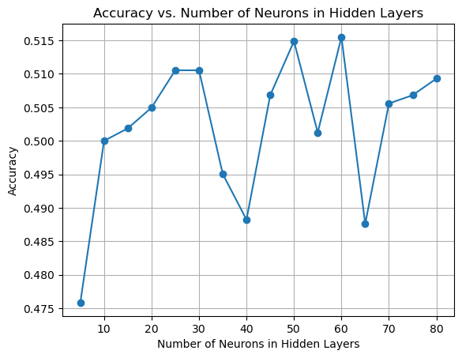

```python
from sklearn.model_selection import train_test_split
from sklearn.neural_network import MLPClassifier
import matplotlib.pyplot as plt

# Preprocessing
X_train = data.drop(columns=['ID', 'Segmentation']).values
y_train = data['Segmentation'].values

# Splitting data into train and validation sets
X_train, X_val, y_train, y_val = train_test_split(X_train, y_train, test_size=0.2, random_state=42)

# Implement a neural network model with 2 layers using MLPClassifier
mlp_2_layers = MLPClassifier(hidden_layer_sizes=(100, 100), max_iter=500, random_state=42)
mlp_2_layers.fit(X_train, y_train)
accuracy_2_layers = mlp_2_layers.score(X_val, y_val)
print("Accuracy of 2-layer MLP:", accuracy_2_layers)

# Repeat with three layers
mlp_3_layers = MLPClassifier(hidden_layer_sizes=(100, 100, 100), max_iter=500, random_state=42)
mlp_3_layers.fit(X_train, y_train)
accuracy_3_layers = mlp_3_layers.score(X_val, y_val)
print("Accuracy of 3-layer MLP:", accuracy_3_layers)

neuron_counts = range(5, 81, 5)  # Modify the range from 5 to 50 with a step of 5
accuracies = []
for neurons in neuron_counts:
    mlp = MLPClassifier(hidden_layer_sizes=(neurons, neurons), max_iter=500, random_state=42)
    mlp.fit(X_train, y_train)
    accuracy = mlp.score(X_val, y_val)
    accuracies.append(accuracy)
    print(f"Accuracy with {neurons} neurons in each hidden layer: {accuracy}")

# Plot a graph with the number of neurons on the X-axis and the corresponding accuracy on the Y-axis
plt.plot(neuron_counts, accuracies, marker='o')
plt.xlabel("Number of Neurons in Hidden Layers")
plt.ylabel("Accuracy")
plt.title("Accuracy vs. Number of Neurons in Hidden Layers")
plt.grid(True)
plt.show()
```

**4. Logistic Regression Implementation:**

• Implement a logistic regression model using scikit-learn as a baseline for comparison.

• Train the model on the same preprocessed dataset.

```python
import pandas as pd
from sklearn.model_selection import train_test_split
from sklearn.linear_model import LogisticRegression
from sklearn.metrics import accuracy_score


# Split the dataset into features (X) and target variable (y)
X = data.drop(columns=['ID', 'Segmentation'])
y = data['Segmentation']

# Split the data into training and testing sets
X_train, X_test, y_train, y_test = train_test_split(X, y, test_size=0.2, random_state=42)

# Initialize and train the logistic regression model
logistic_model = LogisticRegression(max_iter=1000, random_state=42)
logistic_model.fit(X_train, y_train)

# Predict the target variable on the testing set
y_pred = logistic_model.predict(X_test)

# Evaluate the model's performance
accuracy = accuracy_score(y_test, y_pred)
print("Accuracy of logistic regression model:", accuracy)
```

```
Accuracy of logistic regression model: 0.48203221809169766
```

**5. Evaluation and Comparison:**

• Display the learning curve for each model to understand the training process.

• Evaluate the performance of each model using a confusion matrix and classification report.

• Compare the performance of the neural network models with logistic regression, discussing the strengths and weaknesses of each approach.

```
Epoch 0, Sigmoid Loss: 2.4777810910422335, ReLU Loss: 2.5249462147404733
Epoch 100, Sigmoid Loss: 1.6133220618612438, ReLU Loss: 1.6133349504992995
Epoch 200, Sigmoid Loss: 1.613299176000854, ReLU Loss: 1.6133000460667166
Epoch 300, Sigmoid Loss: 1.6132894074860373, ReLU Loss: 1.613287959358385
Epoch 400, Sigmoid Loss: 1.6132839703533788, ReLU Loss: 1.6132818473283546
Epoch 500, Sigmoid Loss: 1.613280494119078, ReLU Loss: 1.6132781641914125
Epoch 600, Sigmoid Loss: 1.6132780723523994, ReLU Loss: 1.613275703147715
Epoch 700, Sigmoid Loss: 1.6132762834987056, ReLU Loss: 1.6132739429188063
Epoch 800, Sigmoid Loss: 1.6132749048125632, ReLU Loss: 1.6132726217140407
Epoch 900, Sigmoid Loss: 1.613273807449015, ReLU Loss: 1.613271593608341
```

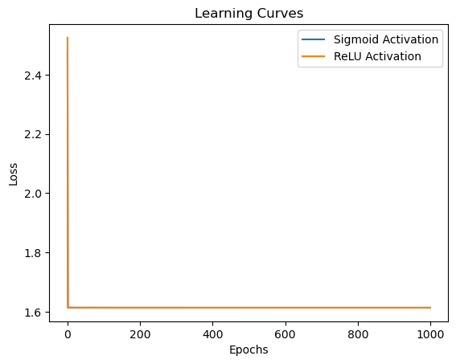

```python
import matplotlib.pyplot as plt
import numpy as np

# Assuming 'data' contains preprocessed data with features X and target y

X = data.drop('Segmentation', axis=1).values
y = data['Segmentation'].values.reshape(-1, 1)

# Normalize features
X = (X - np.mean(X)) / np.std(X)

# Splitting the dataset into training and testing sets (80% train, 20% test)
split = int(0.8 * len(X))
X_train, X_test = X[:split], X[split:]
y_train, y_test = y[:split], y[split:]

# Define neural network parameters
input_size = X_train.shape[1]
hidden_size = 64
output_size = 4  # Number of classes in Segmentation

# Create neural network objects
nn_sigmoid = TwoLayerNN(input_size, hidden_size, output_size, learning_rate=0.0001)
nn_relu = TwoLayerNN(input_size, hidden_size, output_size, learning_rate=0.0001)

# Train the models and collect loss values
epochs = 1000
sigmoid_losses = []
relu_losses = []

for epoch in range(epochs):
    # Forward propagation
    output_sigmoid = nn_sigmoid.forward_propagation(X_train)
    output_relu = nn_relu.forward_propagation(X_train)

    # Backward propagation
    nn_sigmoid.backward_propagation(X_train, y_train)
    nn_relu.backward_propagation(X_train, y_train)

    # Calculate and store the loss
    loss_sigmoid = np.mean(np.square(y_train - output_sigmoid))
    loss_relu = np.mean(np.square(y_train - output_relu))
    sigmoid_losses.append(loss_sigmoid)
    relu_losses.append(loss_relu)

    # Print loss every 100 epochs
    if epoch % 100 == 0:
        print(f"Epoch {epoch}, Sigmoid Loss: {loss_sigmoid}, ReLU Loss: {loss_relu}")

# Plot learning curves
plt.plot(range(epochs), sigmoid_losses, label='Sigmoid Activation')
plt.plot(range(epochs), relu_losses, label='ReLU Activation')
plt.xlabel('Epochs')
plt.ylabel('Loss')
plt.title('Learning Curves')
plt.legend()
plt.show()
```

```python
from sklearn.metrics import confusion_matrix, classification_report

# Evaluate models
print("\nEvaluation with Sigmoid activation:")
y_pred_sigmoid = np.argmax(nn_sigmoid.predict(X_test), axis=1)
print("Confusion Matrix:")
print(confusion_matrix(y_test, y_pred_sigmoid))
print("\nClassification Report:")
print(classification_report(y_test, y_pred_sigmoid))

print("\nEvaluation with ReLU activation:")
y_pred_relu = np.argmax(nn_relu.predict(X_test), axis=1)
print("Confusion Matrix:")
print(confusion_matrix(y_test, y_pred_relu))
print("\nClassification Report:")
print(classification_report(y_test, y_pred_relu))
```

```
Evaluation with Sigmoid activation:
Confusion Matrix:
[[  0   0 392   0]
 [  0   0 362   0]
 [  0   0 410   0]
 [  0   0 450   0]]

Classification Report:
              precision    recall  f1-score   support

           0       0.00      0.00      0.00       392
           1       0.00      0.00      0.00       362
           2       0.25      1.00      0.41       410
           3       0.00      0.00      0.00       450

    accuracy                           0.25      1614
   macro avg       0.06      0.25      0.10      1614
weighted avg       0.06      0.25      0.10      1614


Evaluation with ReLU activation:
Confusion Matrix:
[[  0 392   0   0]
 [  0 362   0   0]
 [  0 410   0   0]
 [  0 450   0   0]]

Classification Report:
              precision    recall  f1-score   support

           0       0.00      0.00      0.00       392
           1       0.22      1.00      0.37       362
           2       0.00      0.00      0.00       410
           3       0.00      0.00      0.00       450

    accuracy                           0.22      1614
   macro avg       0.06      0.25      0.09      1614
weighted avg       0.05      0.22      0.08      1614
```

```
Accuracy of 2-layer MLP: 0.5123915737298637
Accuracy of 3-layer MLP: 0.476456009913259
```

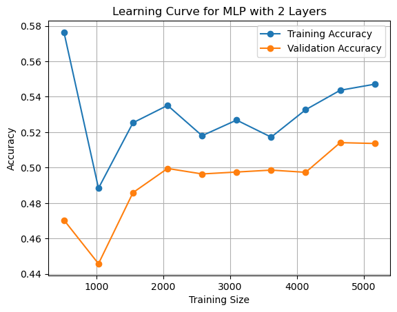

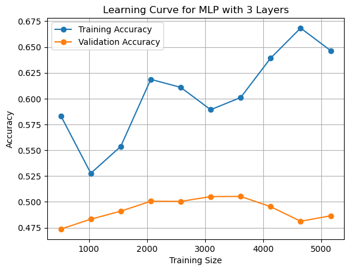

```
Confusion Matrix for MLP with 2 layers:
[[123 133  35 100]
 [ 60 183  82  44]
 [ 29 124 179  48]
 [ 65  58   9 342]]

Classification Report for MLP with 2 layers:
              precision    recall  f1-score   support

           0       0.44      0.31      0.37       391
           1       0.37      0.50      0.42       369
           2       0.59      0.47      0.52       380
           3       0.64      0.72      0.68       474

    accuracy                           0.51      1614
   macro avg       0.51      0.50      0.50      1614
weighted avg       0.52      0.51      0.51      1614

Confusion Matrix for MLP with 3 layers:
[[145  68  78 100]
 [ 91 109 120  49]
 [ 56  76 203  45]
 [ 98  33  31 312]]

Classification Report for MLP with 3 layers:
              precision    recall  f1-score   support

           0       0.37      0.37      0.37       391
           1       0.38      0.30      0.33       369
           2       0.47      0.53      0.50       380
           3       0.62      0.66      0.64       474

    accuracy                           0.48      1614
   macro avg       0.46      0.46      0.46      1614
weighted avg       0.47      0.48      0.47      1614
```

```python
from sklearn.model_selection import train_test_split, learning_curve
from sklearn.metrics import confusion_matrix, classification_report
import matplotlib.pyplot as plt

# Preprocessing
X_train = data.drop(columns=['ID', 'Segmentation']).values
y_train = data['Segmentation'].values

# Splitting data into train and validation sets
X_train, X_val, y_train, y_val = train_test_split(X_train, y_train, test_size=0.2, random_state=42)

# Implement a neural network model with 2 layers using MLPClassifier
mlp_2_layers = MLPClassifier(hidden_layer_sizes=(100, 100), max_iter=500, random_state=42)
mlp_2_layers.fit(X_train, y_train)
accuracy_2_layers = mlp_2_layers.score(X_val, y_val)
print("Accuracy of 2-layer MLP:", accuracy_2_layers)

# Repeat with three layers
mlp_3_layers = MLPClassifier(hidden_layer_sizes=(100, 100, 100), max_iter=500, random_state=42)
mlp_3_layers.fit(X_train, y_train)
accuracy_3_layers = mlp_3_layers.score(X_val, y_val)
print("Accuracy of 3-layer MLP:", accuracy_3_layers)

# Plot learning curves for MLP with 2 layers
train_sizes = np.arange(0.1, 1.1, 0.1)
train_sizes_abs, train_scores, test_scores = learning_curve(
    mlp_2_layers, X_train, y_train, train_sizes=train_sizes, cv=5, scoring='accuracy')

plt.figure()
plt.plot(train_sizes_abs, np.mean(train_scores, axis=1), marker='o', label='Training Accuracy')
plt.plot(train_sizes_abs, np.mean(test_scores, axis=1), marker='o', label='Validation Accuracy')
plt.xlabel('Training Size')
plt.ylabel('Accuracy')
plt.title('Learning Curve for MLP with 2 Layers')
plt.legend()
plt.grid(True)
plt.show()

# Plot learning curves for MLP with 3 layers
train_sizes = np.arange(0.1, 1.1, 0.1)
train_sizes_abs, train_scores, test_scores = learning_curve(
    mlp_3_layers, X_train, y_train, train_sizes=train_sizes, cv=5, scoring='accuracy')

plt.figure()
plt.plot(train_sizes_abs, np.mean(train_scores, axis=1), marker='o', label='Training Accuracy')
plt.plot(train_sizes_abs, np.mean(test_scores, axis=1), marker='o', label='Validation Accuracy')
plt.xlabel('Training Size')
plt.ylabel('Accuracy')
plt.title('Learning Curve for MLP with 3 Layers')
plt.legend()
plt.grid(True)
plt.show()

# Evaluate the performance of MLP with 2 layers using confusion matrix and classification report
y_pred_2_layers = mlp_2_layers.predict(X_val)
print("Confusion Matrix for MLP with 2 layers:")
print(confusion_matrix(y_val, y_pred_2_layers))
print("\nClassification Report for MLP with 2 layers:")
print(classification_report(y_val, y_pred_2_layers))

# Evaluate the performance of MLP with 3 layers using confusion matrix and classification report
y_pred_3_layers = mlp_3_layers.predict(X_val)
print("Confusion Matrix for MLP with 3 layers:")
print(confusion_matrix(y_val, y_pred_3_layers))
print("\nClassification Report for MLP with 3 layers:")
print(classification_report(y_val, y_pred_3_layers))
```

```
Classification Report:
              precision    recall  f1-score   support

           0       0.39      0.43      0.41       391
           1       0.35      0.13      0.19       369
           2       0.44      0.59      0.50       380
           3       0.63      0.72      0.67       474

    accuracy                           0.48      1614
   macro avg       0.45      0.47      0.44      1614
weighted avg       0.46      0.48      0.46      1614
```

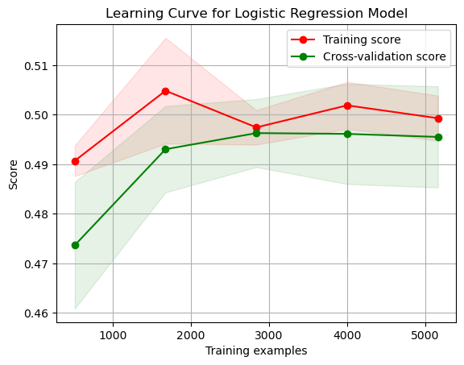

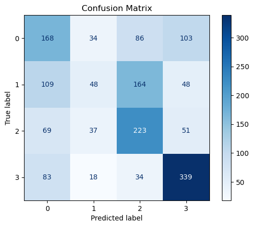

```python
import matplotlib.pyplot as plt
import numpy as np
from sklearn.metrics import plot_confusion_matrix, classification_report
from sklearn.model_selection import learning_curve

# Function to display learning curve
def plot_learning_curve(estimator, title, X, y, ylim=None, cv=None, n_jobs=None, train_sizes=np.linspace(.1, 1.0, 5)):
    plt.figure()
    plt.title(title)
    if ylim is not None:
        plt.ylim(*ylim)
    plt.xlabel("Training examples")
    plt.ylabel("Score")
    train_sizes, train_scores, test_scores = learning_curve(
        estimator, X, y, cv=cv, n_jobs=n_jobs, train_sizes=train_sizes)
    train_scores_mean = np.mean(train_scores, axis=1)
    train_scores_std = np.std(train_scores, axis=1)
    test_scores_mean = np.mean(test_scores, axis=1)
    test_scores_std = np.std(test_scores, axis=1)
    plt.grid()

    plt.fill_between(train_sizes, train_scores_mean - train_scores_std,
                     train_scores_mean + train_scores_std, alpha=0.1,
                     color="r")
    plt.fill_between(train_sizes, test_scores_mean - test_scores_std,
                     test_scores_mean + test_scores_std, alpha=0.1, color="g")
    plt.plot(train_sizes, train_scores_mean, 'o-', color="r",
             label="Training score")
    plt.plot(train_sizes, test_scores_mean, 'o-', color="g",
             label="Cross-validation score")

    plt.legend(loc="best")
    return plt

# Display learning curve for logistic regression model
plot_learning_curve(logistic_model, "Learning Curve for Logistic Regression Model", X_train, y_train, cv=5)

# Generate confusion matrix
disp = plot_confusion_matrix(logistic_model, X_test, y_test, cmap=plt.cm.Blues, normalize=None)
disp.ax_.set_title("Confusion Matrix")

# Generate classification report
class_report = classification_report(y_test, y_pred)
print("Classification Report:")
print(class_report)

plt.show()
```

**Logistic Regression:** Accuracy: 0.48 Precision, recall, and F1-score for each class are provided in the classification report. The confusion matrix shows the number of true positive, false positive, true negative, and false negative predictions for each class.

**MLP with 2 layers:** Accuracy: 0.51 Precision, recall, and F1-score for each class are provided in the classification report. The confusion matrix shows the number of true positive, false positive, true negative, and false negative predictions for each class.

**MLP with 3 layers:** Accuracy: 0.48 Precision, recall, and F1-score for each class are provided in the classification report. The confusion matrix shows the number of true positive, false positive, true negative, and false negative predictions for each class.

**Comparison and Discussion:**

**Logistic Regression:** Strengths: Simple and interpretable, works well with linearly separable data, less prone to overfitting with small datasets. Weaknesses: Limited capacity to capture complex relationships in the data, assumes linear relationship between features and target.

**MLP with 2 layers and MLP with 3 layers:** Strengths: Can capture complex non-linear relationships in the data, suitable for high-dimensional data, flexibility in architecture and activation functions. Weaknesses: Prone to overfitting with insufficient data or excessive model capacity, requires careful tuning of hyperparameters, longer training time compared to logistic regression.

**Sigmoid Activation and ReLU Activation:** Strengths: Can capture non-linear relationships, suitable for classification tasks, flexibility in activation functions. Weaknesses: May suffer from vanishing gradient problem with deep architectures, sensitivity to hyperparameters and initialization, interpretability may be challenging.

In summary, logistic regression is a simpler and more interpretable model suitable for linearly separable data or when interpretability is important. On the other hand, MLPs offer greater flexibility and can capture complex non-linear relationships, but they require more data, tuning, and computational resources. The choice between logistic regression and MLP depends on the nature of the data, the desired level of interpretability, and the trade-off between model complexity and performance